# Introduction to PhysioSpaceMethods

A. H. Esfahani

PhysioSpace is a robust statistical method for relating high dimensional omics data sets[^1]. It is designed to take advantage of the vast availability of public omics data, which in combination with statistical approaches makes a potent tool capable of analyzing heterogeneous biological data sets.

PhysioSpaceMethods is a R package which provides an implementation of PhysioSpace method alongside other handy functions for making PhysioSpace an easily accessible tool for R users.

# Installation Instructions

You can install this package by:

```r
if (!requireNamespace("remotes", quietly = TRUE))
    install.packages("remotes")
remotes::install_gitlab("jrc-combine/PhysioSpaceMethods", host = "git.rwth-aachen.de")
```

# Usage Instructions

PhysioSpaceMethods can map user samples inside a physiological space, calculated beforehand from a compendium of known samples. This process is demonstrated here by an example.

Before running through the example, we load all required packages of the vignette:

```r
library(SummarizedExperiment) #SummarizedExperiment is needed for
                            #working with RangedSummarizedExperiment objects.
library(EnrichmentBrowser)  # For converting IDs of a
                            # RangedSummarizedExperiment object.
library(org.Hs.eg.db) #For ID conversion
library(ExperimentHub) #Downloads datasets from ExperimentHub web service
library(PhysioSpaceMethods) #Main package
```

# E-MTAB-2836 Analysis Using PhysioSpaceMethods

The data set used in this example is [E-MTAB-2836](https://www.ebi.ac.uk/gxa/experiments/E-MTAB-2836/), a RNA-seq atlas of coding RNA from tissue samples of 122 **human** individuals representing 32 different tissues, stored on ebi's [Expression Atlas](https://www.ebi.ac.uk/gxa/home).

Before starting the analysis, we need a physiological space in which we could map E-MTAB-2836 samples. There are spaces available in 'HumanPhysioSpace' package, accessible at https://github.com/JRC-COMBINE/HumanPhysioSpace. For demonstration purposes, we won't use that package. Instead, we will make a new physiological space in the next section, and use it through the rest of this vignette.

## Making a PhysioSpace out of Lukk et. al. human atlas

In this section we use lukk et. al. human atlas[^2] to make a human tissue space.

Lukk et. al. atlas is generated using DNA-microarray (Affymetrix Human Genome U133A Array). We chose this data set for analyzing E-MTAB-2836 (RNA-Seq) to demonstrate PhysioSpace robustness against measurement technology, normalization or batch effects.

In the first step, we download the Lukk atlas gene expression data from [ExperimentHub](https://bioconductor.org/packages/release/bioc/html/ExperimentHub.html):

```r
hub <- ExperimentHub()
HumanAffys <- query(hub, "HumanAffyData")
LukkData <- HumanAffys[["EH177"]]
```

We have to prepare the gene expression data set for the function spaceMaker(). spaceMaker expects a matrix of input gene expressions (or a SummarizedExperiment object), with genes as rows and samples as columns. LukkData is an ExpressionSet object, so we will use exprs() function from Biobase package to extract the expression matrix:

```r
LukkDataMatrix <- exprs(LukkData)
```

Corresponding Entrez Gene IDs must be assigned to 'rownames', and name of each sample should be written in 'colnames' of the matrix. Rownames of LukkDataMatrix already contain Entrez IDs of each gene. But as for the sample names, we have to extract them from LukkData using pData() function and assign them to colnames of LukkDataMatrix:

```r
colnames(LukkDataMatrix) <- make.names(pData(LukkData)$Groups_369)
#'make.names' is used so that some specific names won't break the pipeline
#later on.
```

spaceMaker uses (linear) modeling and statistical testing while generating the mathematical space. In that process, it needs one or few 'Control' or 'Reference' samples. It assumes the first column (or all samples with the same label as the first column) to be the reference of the experiment and uses it as control. In this experiment, we use the mean value of all samples as control:

```r
LukkDataMatrix <- cbind(apply(LukkDataMatrix,1,mean),LukkDataMatrix)
colnames(LukkDataMatrix)[1] <- "Ctrl"
```

LukkDataMatrix is ready to be used by spaceMaker():

```r
LukkSpace <- spaceMaker(GeneExMatrix = LukkDataMatrix)
```

## E-MTAB-2836 Preparation

E-MTAB-2836 can be downloaded manually from [this page (the "Summary of the expression results for this experiment ready to view in R"" link)](https://www.ebi.ac.uk/gxa/experiments/E-MTAB-2836/Downloads), or loaded directly into R by the following command:

```r
#Download:
load(url(paste0("https://www.ebi.ac.uk/gxa/experiments-content/",
                "E-MTAB-2836/static/E-MTAB-2836-atlasExperimentSummary.Rdata")))
```

After downloading (and normalizing if necessary), the data can be analysed using "calculatePhysioMap()" function. It is important to note that 'InputData' of this function has specific format requirements which are needed to be met for the function to perform properly. Detailed description of input requirements can be found in calculatePhysioMap's help page. In short,

1. In case InputData is a **matrix**, it should be:
   1. a matrix (clearly),
   2. with genes in rows, identified by Entrez IDs which are stored in 'rownames' of the matrix. And
   3. samples in columns, identified by sample names stored in 'colnames' of the matrix. Lastly,
   4. values of InputData matrix should be **relative**, e.g. fold changes of genes, rather than pure gene expressions.
2. In case InputData is a **SummarizedExperiment object**, it is supposed to have:
   1. a component named 'EntrezID' in its rowData, containing Entrez IDs of rows in the object. And
   2. a component named 'SampleName' in its colData, containing name or the main annotation of the samples in the object. Lastly,
   3. the assay in the SummarizedExperiment object (accessible by using SummarizedExperiment::assay(obj)) has to have **relative** values, e.g. fold changes of genes, rather than pure gene expressions.
3. In case user has their own list of significantly up and down regulated genes, it is also possible for InputData to be a list:
   1. containing Entrez IDs (or any other identifier which is used as rownames in 'Space') of up regulated genes in InputData[[1]], and
   2. Entrez IDs (or any other identifier which is used as rownames in 'Space') of down regulated genes in InputData[[2]].

For demonstration purposes, in this example we prepare the InputData as a matrix, and also as a SummarizedExperiment.

### E-MTAB-2836 InputData as a matrix

We prepare E-MTAB-2836 for calculatePhysioMap() in four steps:

- **Converting gene expression data into a matrix:** In this example E-MTAB-2836-atlasExperimentSummary.Rdata contains a RangedSummarizedExperiment object, from which we have to extract a gene expression matrix:

  ```r
  #Making the gene expression matrix:
  EMTAB2836CountMatrix <- assay(experimentSummary$rnaseq)
  ```

- **Having genes in rows and samples in columns, with Entrez IDs in rownames:** After converting the gene expression data to a matrix, we have to make sure that the matrix has genes in rows and samples in columns, with genes identified by Entrez IDs stored in 'rownames' of the matrix. In EMTAB2836CountMatrix genes are already in rows and samples are in columns. However, Ensembl IDs, stored in rownames, have to be converted to Entrez IDs. There are numerous ways for this conversion. For example by using Ensembl's [BioMart](https://www.ensembl.org/biomart/martview/) or [biomaRt's package](https://bioconductor.org/packages/release/bioc/html/biomaRt.html) in R. Here we used bioconductor's org.Hs.eg.db annotation package:

  ```r
  #Converting Ensembl to Entrez IDs:
  ENSEMBL2EG <- as.list(org.Hs.egENSEMBL2EG)
  IDIndx <- match(rownames(EMTAB2836CountMatrix), names(ENSEMBL2EG), nomatch = 0)
  EMTAB2836CountMatrix <- EMTAB2836CountMatrix[IDIndx!=0,]
  rownames(EMTAB2836CountMatrix) <- sapply(ENSEMBL2EG[IDIndx], function(x) x[1])
  ```

- **Writing sample names in colnames:** This step is not necessary for proper calculation, but it is highly recommended as it helps in proper inference of the result matrix. Sample names should be short, and to the point. Since in this example we aim to match RNA-seq counts of different human tissues to their corresponding tissues in a micro-array compendium, we use the tissue names as colnames of EMTAB2836CountMatrix:

  ```r
  #Assigning colnames:
  colnames(EMTAB2836CountMatrix) <-
                          colData(experimentSummary$rnaseq)$organism_part
  ```

- **Having *RELATIVE* values for gene expression:** PhysioSpace method expects relative values as input, i.e. it assumes the most positive values correspond to up-regulated genes and most negative values correspond to down-regulated genes. Easiest way to calculate this relative value is by calculating fold change, although more proper statistical tests could result in better performance. In this specific example we use fold change:

  ```r
  #Calculating Fold-Changes:
  EMTAB2836CountMatrixRelativ <- EMTAB2836CountMatrix -
                                      apply(EMTAB2836CountMatrix,1,mean)
  ```

  We used the gene-wise mean value of the whole data set as a virtual control sample and calculated the fold changes based on this virtual control, since all data points in E-MTAB-2836 are biopsy samples and there are no actual control samples. At the same time, because of the high number of samples in E-MTAB-2836, the mean value is a good measure of background noise on each gene. Therefore, mean values work great as controls to compare against. As mentioned above, there are more sophisticated ways for this calculation, one example could be to use the signed p value of a statistical test in logarithm scale.

### E-MTAB-2836 InputData as a SummarizedExperiment object

As an alternative, InputData could be a SummarizedExperiment object when passed to the calculatePhysioMap() function. Here, we prepare the object in three steps:

- **Setting up 'EntrezID' component in rowData:** After loading E-MTAB-2836 into working environment, we have to add a component named 'EntrezID' to row data of the loaded object. This new added component should contain Entrez IDs of the rows of data in the SummarizedExperiment object:

  ```r
  #Loading the object into R:
  EMTAB2836_SEObj <- experimentSummary$rnaseq
  #
  #Converting Ensembl to Entrez IDs:
  EMTAB2836_SEObj <- idMap(EMTAB2836_SEObj, org="hsa",
                                              from="ENSEMBL", to="ENTREZID")
  #Making EntrezID in rowData:
  rowData(EMTAB2836_SEObj) <- data.frame("EntrezID" =
                                         rownames(EMTAB2836_SEObj))
  ```

  We used idMap function from [EnrichmentBrowser package](https://bioconductor.org/packages/release/bioc/html/EnrichmentBrowser.html) for converting Ensembl to Entrez IDs. Alternatively, we could use org.Hs.eg.db annotation package:

  ```r
  EMTAB2836_SEObj <- experimentSummary$rnaseq
  #
  #Converting Ensembl to Entrez IDs, and making EntrezID in rowData:
  ENSEMBL2EG <- as.list(org.Hs.egENSEMBL2EG)
  IDIndx <- match(rownames(EMTAB2836_SEObj), names(ENSEMBL2EG), nomatch = 0)
  EMTAB2836_SEObj <- EMTAB2836_SEObj[IDIndx!=0,]
  rowData(EMTAB2836_SEObj) <- data.frame("EntrezID" =
            sapply(ENSEMBL2EG[IDIndx], function(x) x[1]))
  ```

- **Setting up 'SampleName' component in colData:** This step is not necessary for proper calculation, but it is highly recommended as it helps in proper inference of the result matrix. We have to assign a component named 'SampleName' to col data of the object, which contains the main annotation of samples in the data set under analysis. In this example, we aim to detect the tissue type of samples in E-MTAB-2836. So our target annotation is the source tissue name of each sample, already available as 'organism_part' component of column data. But we have to rename 'organism_part' to 'SampleName':

  ```r
  #Assigning SampleName:
  names(colData(EMTAB2836_SEObj))[names(colData(EMTAB2836_SEObj)) ==
                                  "organism_part"] <- "SampleName"
  ```

- **Having *RELATIVE* values in Assay:** PhysioSpace method expects relative values is assay of SummarizedExperiment input object, i.e. it assumes the most positive values correspond to up-regulated genes and most negative values correspond to down-regulated genes. As mentioned above, in this example we use universal mean as control and calculate fold changes based on that reference:

  ```r
  #Calculating Fold-Changes:
  assay(EMTAB2836_SEObj) <- assay(EMTAB2836_SEObj) -
                                      apply(assay(EMTAB2836_SEObj),1,mean)
  ```

Having the proper format for the input, the main calculation can be done easily by the calculatePhysioMap() function.

## E-MTAB-2836 Analysis

```r
#Choosing 5 random samples:
set.seed(seed = 0) #So results would be reproducible
Samples5Random <- sample(x = 1:ncol(EMTAB2836CountMatrixRelativ), size = 5)
#Main calculation:
RESULTS5 <- calculatePhysioMap(
    InputData = EMTAB2836CountMatrixRelativ[,Samples5Random],
    Space = LukkSpace)
```

```r
#Main calculation, for SummarizedExperiment input obj.:
RESULTS5_SE <- calculatePhysioMap(
    InputData = EMTAB2836_SEObj[,Samples5Random],
    Space = LukkSpace)
```

```r
#Check to see if the results are the same, regardless of input format:
identical(RESULTS5, RESULTS5_SE)
```

[output not shown]

As expected, results are the same for both input types of matrix and SummarizedExperiment obj.. In this vignette from here onward, we do all the calculations in the matrix format.

In cases with large number of input samples, we recommend running calculatePhysioMap() in parallel:

```r
#Main calculation in parallel:
RESULTS5 <- calculatePhysioMap(
    InputData = EMTAB2836CountMatrixRelativ[,Samples5Random],
    Space = LukkSpace, NumbrOfCores = 2)
```

The output of calculatePhysioMap(), which we named 'RESULTS5', is a matrix with the same number of columns as the number of samples in 'InputData', and the same number of rows as the number of axes (Columns) in the 'Space'. The value in row M and Column N in RESULTS5 is the mapped values of N<sup>th</sup> sample on M<sup>th</sup> axis of the Space.

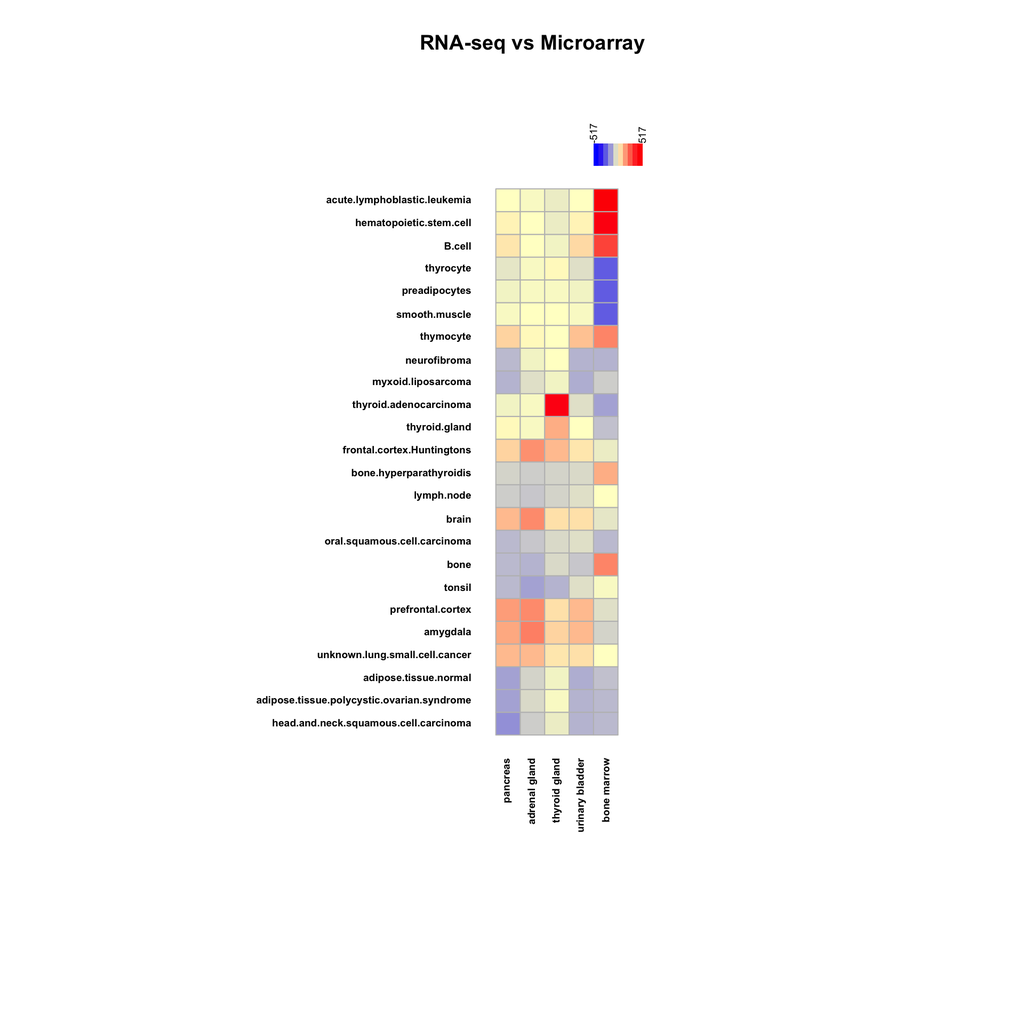

```r
#Plotting the results:
PhysioHeatmap(PhysioResults = RESULTS5, main = "RNA-seq vs Microarray",
            SymmetricColoring = TRUE, SpaceClustering = FALSE,
            Space = LukkSpace, ReducedPlotting = 5)
```

[^1]: Lenz, Michael, et al. "PhysioSpace: relating gene expression experiments from heterogeneous sources using shared physiological processes." PLoS One 8.10 (2013): e77627
[^2]: Lukk, Margus, et al. "A global map of human gene expression." Nature biotechnology 28.4 (2010): 322.
[^3]: https://en.wikipedia.org/wiki/Myometrium